# Introduction

# Relationship between Food Insecurity, Physical Inactivity, and Health

```
object
count     2715
unique       5
top         Q4
freq       558
Name: Food.Insecurity.Quintile, dtype: object
```

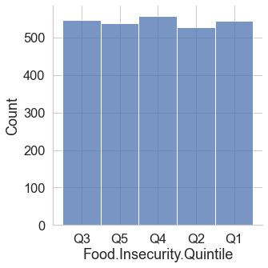

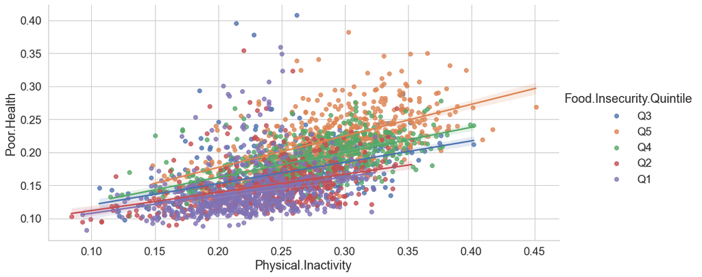

```
                            OLS Regression Results
==============================================================================
Dep. Variable:       Q("Poor.Health")   R-squared:                       0.364
Model:                            OLS   Adj. R-squared:                  0.364
Method:                 Least Squares   F-statistic:                     1551.
Date:                Wed, 16 Mar 2022   Prob (F-statistic):          9.88e-269
Time:                        20:19:28   Log-Likelihood:                 5170.8
No. Observations:                2715   AIC:                        -1.034e+04
Df Residuals:                    2713   BIC:                        -1.033e+04
Df Model:                           1
Covariance Type:            nonrobust
============================================================================================
                               coef    std err          t      P>|t|      [0.025      0.975]
--------------------------------------------------------------------------------------------
Intercept                    0.0397      0.003     11.375      0.000       0.033       0.047
Q("Physical.Inactivity")     0.5267      0.013     39.386      0.000       0.501       0.553
==============================================================================
Omnibus:                      670.074   Durbin-Watson:                   1.296
Prob(Omnibus):                  0.000   Jarque-Bera (JB):             2295.968
Skew:                           1.209   Prob(JB):                         0.00
Kurtosis:                       6.801   Cond. No.                         20.6
==============================================================================

Notes:
[1] Standard Errors assume that the covariance matrix of the errors is correctly specified.
                            OLS Regression Results
==============================================================================
Dep. Variable:       Q("Poor.Health")   R-squared:                       0.522
Model:                            OLS   Adj. R-squared:                  0.521
Method:                 Least Squares   F-statistic:                     592.1
Date:                Wed, 16 Mar 2022   Prob (F-statistic):               0.00
Time:                        20:19:28   Log-Likelihood:                 5559.4
No. Observations:                2715   AIC:                        -1.111e+04
Df Residuals:                    2709   BIC:                        -1.107e+04
Df Model:                           5
Covariance Type:            nonrobust
=======================================================================================================
                                          coef    std err          t      P>|t|      [0.025      0.975]
-------------------------------------------------------------------------------------------------------
Intercept                               0.0626      0.003     19.550      0.000       0.056       0.069
```

[output cut: 32 more lines]

```
Q("Food.Insecurity.Quintile")[T.Q5]                              0.0011      0.012      0.099      0.921      -0.021       0.024
Q("Physical.Inactivity")                                         0.2741      0.035      7.772      0.000       0.205       0.343
Q("Physical.Inactivity"):Q("Food.Insecurity.Quintile")[T.Q2]     0.0011      0.047      0.023      0.982      -0.090       0.093
Q("Physical.Inactivity"):Q("Food.Insecurity.Quintile")[T.Q3]     0.0487      0.044      1.098      0.272      -0.038       0.136
Q("Physical.Inactivity"):Q("Food.Insecurity.Quintile")[T.Q4]     0.1043      0.044      2.367      0.018       0.018       0.191
Q("Physical.Inactivity"):Q("Food.Insecurity.Quintile")[T.Q5]     0.2035      0.045      4.514      0.000       0.115       0.292
==============================================================================
Omnibus:                     1233.800   Durbin-Watson:                   1.620
Prob(Omnibus):                  0.000   Jarque-Bera (JB):             9660.130
Skew:                           1.982   Prob(JB):                         0.00
Kurtosis:                      11.347   Cond. No.                         159.
==============================================================================

Notes:
[1] Standard Errors assume that the covariance matrix of the errors is correctly specified.
```

```python
## Summary of X var
print(county_data["Food.Insecurity.Quintile"].dtypes)

print(county_data["Food.Insecurity.Quintile"].describe())
sns.displot(county_data["Food.Insecurity.Quintile"]);

sns.lmplot(x="Physical.Inactivity", y="Poor.Health", hue="Food.Insecurity.Quintile", data=county_data, height=6,
aspect=2);
plt.show()

health_reg = smf.ols(formula = 'Q("Poor.Health") ~ Q("Physical.Inactivity")', data = county_data)
health_reg_res = health_reg.fit()
print(health_reg_res.summary())

insec_reg = smf.ols(formula = 'Q("Poor.Health") ~ Q("Physical.Inactivity") + Q("Food.Insecurity.Quintile")',
                       data = county_data)
insec_reg_res = insec_reg.fit()
print(insec_reg_res.summary())

insec_health_phys = smf.ols(formula = 'Q("Poor.Health") ~ Q("Physical.Inactivity") + Q("Food.Insecurity.Quintile") + Q("Physical.Inactivity"):Q("Food.Insecurity.Quintile")', data = county_data)
insec_health_phys_res = insec_health_phys.fit()
print(insec_health_phys_res.summary())
```

# Relationship between Adult Obesity, Physical Inactivity, and Health

```
float64
count    2715.000000
mean        0.320086
std         0.045581
min         0.138000
25%         0.294000
50%         0.323000
75%         0.350000
max         0.495000
Name: Adult.Obesity, dtype: float64
```

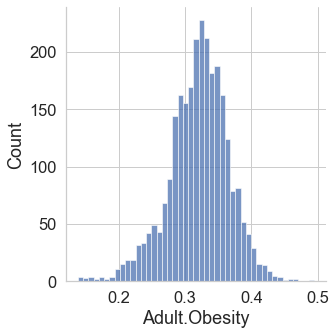

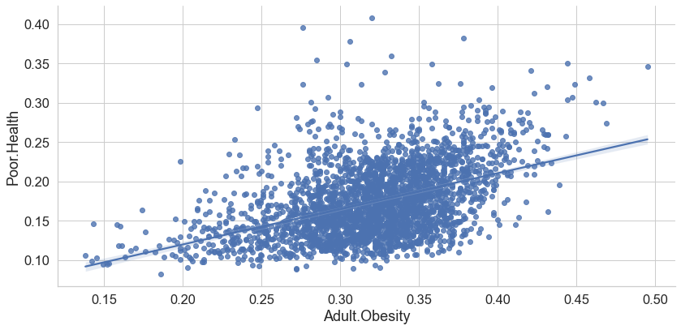

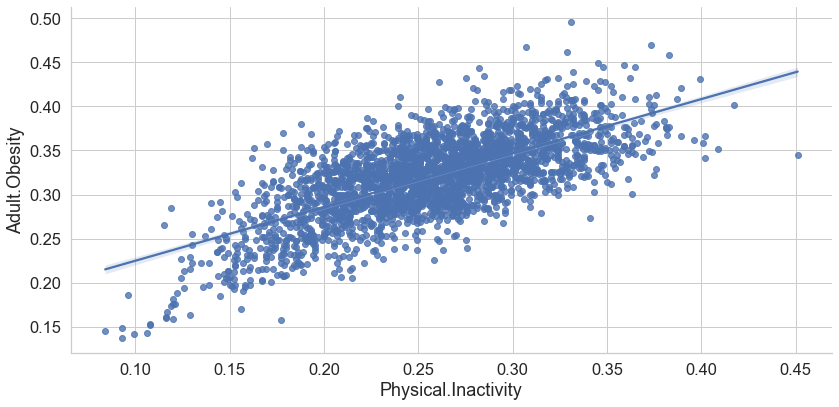

```
                            OLS Regression Results
==============================================================================
Dep. Variable:       Q("Poor.Health")   R-squared:                       0.208
Model:                            OLS   Adj. R-squared:                  0.208
Method:                 Least Squares   F-statistic:                     713.9
Date:                Wed, 16 Mar 2022   Prob (F-statistic):          8.01e-140
Time:                        20:19:34   Log-Likelihood:                 4874.0
No. Observations:                2715   AIC:                            -9744.
Df Residuals:                    2713   BIC:                            -9732.
Df Model:                           1
Covariance Type:            nonrobust
======================================================================================
                         coef    std err          t      P>|t|      [0.025      0.975]
--------------------------------------------------------------------------------------
Intercept              0.0296      0.005      5.405      0.000       0.019       0.040
Q("Adult.Obesity")     0.4524      0.017     26.719      0.000       0.419       0.486
==============================================================================
Omnibus:                      358.496   Durbin-Watson:                   1.053
Prob(Omnibus):                  0.000   Jarque-Bera (JB):              695.259
Skew:                           0.826   Prob(JB):                    1.06e-151
Kurtosis:                       4.848   Cond. No.                         24.2
==============================================================================

Notes:
[1] Standard Errors assume that the covariance matrix of the errors is correctly specified.
                            OLS Regression Results
==============================================================================
Dep. Variable:       Q("Poor.Health")   R-squared:                       0.367
Model:                            OLS   Adj. R-squared:                  0.366
Method:                 Least Squares   F-statistic:                     785.0
Date:                Wed, 16 Mar 2022   Prob (F-statistic):          1.10e-269
Time:                        20:19:34   Log-Likelihood:                 5176.9
No. Observations:                2715   AIC:                        -1.035e+04
Df Residuals:                    2712   BIC:                        -1.033e+04
Df Model:                           2
Covariance Type:            nonrobust
============================================================================================
                               coef    std err          t      P>|t|      [0.025      0.975]
--------------------------------------------------------------------------------------------
Intercept                    0.0276      0.005      5.646      0.000       0.018       0.037
```

[output cut: 23 more lines]

```
                                                  coef    std err          t      P>|t|      [0.025      0.975]
---------------------------------------------------------------------------------------------------------------
Intercept                                       0.1880      0.017     11.068      0.000       0.155       0.221
Q("Physical.Inactivity")                       -0.2145      0.073     -2.937      0.003      -0.358      -0.071
Q("Adult.Obesity")                             -0.4361      0.056     -7.826      0.000      -0.545      -0.327
Q("Physical.Inactivity"):Q("Adult.Obesity")     2.1663      0.220      9.844      0.000       1.735       2.598
==============================================================================
Omnibus:                      714.311   Durbin-Watson:                   1.305
Prob(Omnibus):                  0.000   Jarque-Bera (JB):             2759.601
Skew:                           1.249   Prob(JB):                         0.00
Kurtosis:                       7.261   Cond. No.                         380.
==============================================================================

Notes:
[1] Standard Errors assume that the covariance matrix of the errors is correctly specified.
```

```python
## Summary of X var
print(county_data["Adult.Obesity"].dtypes)

print(county_data["Adult.Obesity"].describe())
sns.displot(county_data["Adult.Obesity"]);

sns.lmplot(x="Adult.Obesity", y="Poor.Health", data=county_data, height=6,
aspect=2);
plt.show()

sns.lmplot(x="Physical.Inactivity", y="Adult.Obesity", data=county_data, height=6,
aspect=2);
plt.show()

health_reg2 = smf.ols(formula = 'Q("Poor.Health") ~ Q("Adult.Obesity")', data = county_data)
health_reg_res2 = health_reg2.fit()
print(health_reg_res2.summary())

obes_reg = smf.ols(formula = 'Q("Poor.Health") ~ Q("Physical.Inactivity") + Q("Adult.Obesity")',
                       data = county_data)
obes_reg_res = obes_reg.fit()
print(obes_reg_res.summary())

obes_health_phys = smf.ols(formula = 'Q("Poor.Health") ~ Q("Physical.Inactivity") + Q("Adult.Obesity") + Q("Physical.Inactivity"):Q("Adult.Obesity")', data = county_data)
obes_health_phys_res = obes_health_phys.fit()
print(obes_health_phys_res.summary())
```

- I then wanted to introduce another variable and examine the relationship between physical inactivity and adult obesity. I chose adult obesity because it logically follows that obesity follows from physical inactivity.
- Then, I plotted the relationships between adult obesity and poor health as well as physical inactivity and adult obesity. Although there was a lot of variability in points, there was a general positive relationship between adult obesity and poor health as well as physical inactivity and adult obesity.
- I then ran three different regressions to see the different associations between each of the variables. For the first regression, I just ran adult obestity as a predictor variable. For the second, I ran physical inactivity and adult obesity as predictor variables. Finally, I ran physical inactivity and adult obesity as well as their interaction as predictor variables to see the effect of physical inactivity on the value of another adult obesity.
- For the first model, the R squared value of .208 indicates that adult obesity does not strongly explain the variability in poor health. The p value is 0, indicating that adult obesity is a significant predictor of poor health.
- For the second model, the R squared value of .367 indicates that physical inactivity and adult obesity does not strongly explain the variability in poor health. The p value is 0, indicating that physical inactivity and adult obesity are significant predictors of poor health.
- For the third model, the R squared value of .388 indicates that physical inactivity, adult obesity, and their interaction does not strongly explain the variability in poor health. All of the predictors are significant when the interaction model was introduced, since their p values were less than .05.

# Relationship between Proportion.of.Smokers, Physical Inactivity, and Health

```
float64
count    2715.000000
mean        0.178243
std         0.034748
min         0.067354
25%         0.152513
50%         0.173543
75%         0.202849
max         0.331744
Name: Proportion.of.Smokers, dtype: float64
```

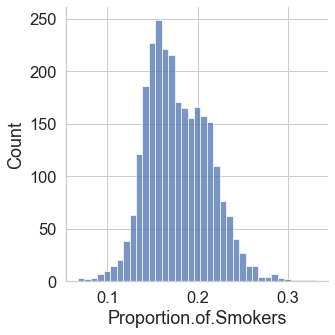

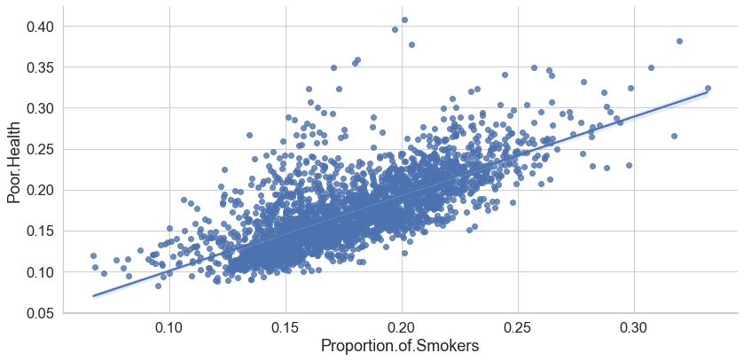

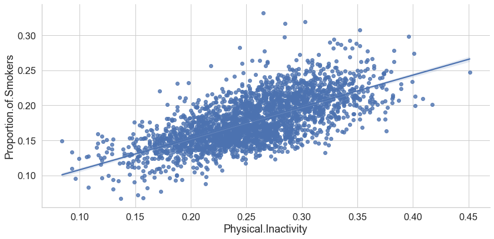

```
                            OLS Regression Results
==============================================================================
Dep. Variable:       Q("Poor.Health")   R-squared:                       0.524
Model:                            OLS   Adj. R-squared:                  0.524
Method:                 Least Squares   F-statistic:                     2986.
Date:                Wed, 16 Mar 2022   Prob (F-statistic):               0.00
Time:                        20:19:37   Log-Likelihood:                 5564.6
No. Observations:                2715   AIC:                        -1.113e+04
Df Residuals:                    2713   BIC:                        -1.111e+04
Df Model:                           1
Covariance Type:            nonrobust
==============================================================================================
                                 coef    std err          t      P>|t|      [0.025      0.975]
----------------------------------------------------------------------------------------------
Intercept                      0.0066      0.003      2.122      0.034       0.001       0.013
Q("Proportion.of.Smokers")     0.9411      0.017     54.647      0.000       0.907       0.975
==============================================================================
Omnibus:                      858.796   Durbin-Watson:                   0.981
Prob(Omnibus):                  0.000   Jarque-Bera (JB):             3470.537
Skew:                           1.502   Prob(JB):                         0.00
Kurtosis:                       7.654   Cond. No.                         29.7
==============================================================================

Notes:
[1] Standard Errors assume that the covariance matrix of the errors is correctly specified.
                            OLS Regression Results
==============================================================================
Dep. Variable:       Q("Poor.Health")   R-squared:                       0.549
Model:                            OLS   Adj. R-squared:                  0.549
Method:                 Least Squares   F-statistic:                     1651.
Date:                Wed, 16 Mar 2022   Prob (F-statistic):               0.00
Time:                        20:19:37   Log-Likelihood:                 5637.9
No. Observations:                2715   AIC:                        -1.127e+04
Df Residuals:                    2712   BIC:                        -1.125e+04
Df Model:                           2
Covariance Type:            nonrobust
==============================================================================================
                                 coef    std err          t      P>|t|      [0.025      0.975]
----------------------------------------------------------------------------------------------
Intercept                     -0.0078      0.003     -2.398      0.017      -0.014      -0.001
```

[output cut: 23 more lines]

```
                                                          coef    std err          t      P>|t|      [0.025      0.975]
-----------------------------------------------------------------------------------------------------------------------
Intercept                                               0.1039      0.013      7.801      0.000       0.078       0.130
Q("Physical.Inactivity")                               -0.2448      0.052     -4.700      0.000      -0.347      -0.143
Q("Proportion.of.Smokers")                              0.0925      0.080      1.159      0.246      -0.064       0.249
Q("Physical.Inactivity"):Q("Proportion.of.Smokers")     2.4916      0.288      8.645      0.000       1.926       3.057
==============================================================================
Omnibus:                     1105.150   Durbin-Watson:                   1.087
Prob(Omnibus):                  0.000   Jarque-Bera (JB):             6628.047
Skew:                           1.828   Prob(JB):                         0.00
Kurtosis:                       9.725   Cond. No.                         552.
==============================================================================

Notes:
[1] Standard Errors assume that the covariance matrix of the errors is correctly specified.
```

```python
## Summary of X var
print(county_data["Proportion.of.Smokers"].dtypes)

print(county_data["Proportion.of.Smokers"].describe())
sns.displot(county_data["Proportion.of.Smokers"]);

sns.lmplot(x="Proportion.of.Smokers", y="Poor.Health",data=county_data, height=6, aspect=2);
plt.show()

sns.lmplot(x="Physical.Inactivity", y="Proportion.of.Smokers", data=county_data, height=6,
aspect=2);
plt.show()

health_reg3 = smf.ols(formula = 'Q("Poor.Health") ~ Q("Proportion.of.Smokers")', data = county_data)
health_reg_res3 = health_reg3.fit()
print(health_reg_res3.summary())

smoke_reg = smf.ols(formula = 'Q("Poor.Health") ~ Q("Physical.Inactivity") + Q("Proportion.of.Smokers")',
                       data = county_data)
smoke_reg_res = smoke_reg.fit()
print(smoke_reg_res.summary())

smoke_health_phys = smf.ols(formula = 'Q("Poor.Health") ~ Q("Physical.Inactivity") + Q("Proportion.of.Smokers") + Q("Physical.Inactivity"):Q("Proportion.of.Smokers")', data = county_data)
smoke_health_phys_res = smoke_health_phys.fit()
print(smoke_health_phys_res.summary())
```

# Relationship between Excessive.Drinking, Physical Inactivity, and Health

```
float64
count    2715.000000
mean        0.174894
std         0.031926
min         0.092652
25%         0.152109
50%         0.174272
75%         0.196637
max         0.294401
Name: Excessive.Drinking, dtype: float64
```

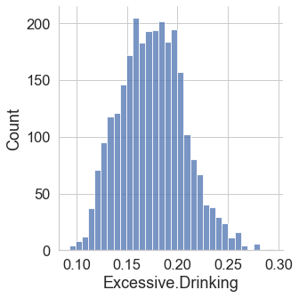

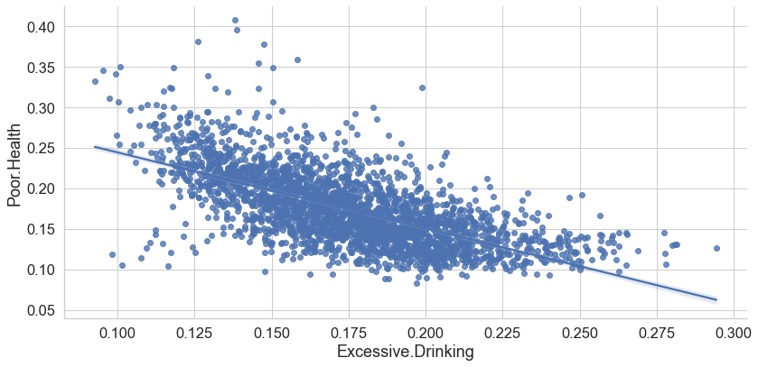

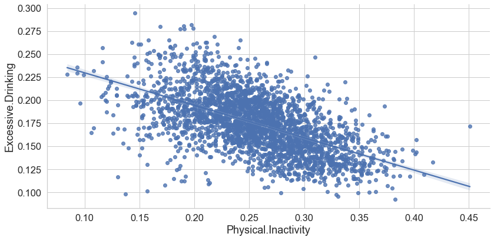

```
                            OLS Regression Results
==============================================================================
Dep. Variable:       Q("Poor.Health")   R-squared:                       0.436
Model:                            OLS   Adj. R-squared:                  0.436
Method:                 Least Squares   F-statistic:                     2100.
Date:                Wed, 16 Mar 2022   Prob (F-statistic):               0.00
Time:                        20:19:44   Log-Likelihood:                 5335.3
No. Observations:                2715   AIC:                        -1.067e+04
Df Residuals:                    2713   BIC:                        -1.065e+04
Df Model:                           1
Covariance Type:            nonrobust
===========================================================================================
                              coef    std err          t      P>|t|      [0.025      0.975]
-------------------------------------------------------------------------------------------
Intercept                   0.3379      0.004     93.179      0.000       0.331       0.345
Q("Excessive.Drinking")    -0.9347      0.020    -45.830      0.000      -0.975      -0.895
==============================================================================
Omnibus:                      285.596   Durbin-Watson:                   1.220
Prob(Omnibus):                  0.000   Jarque-Bera (JB):              761.323
Skew:                           0.584   Prob(JB):                    4.79e-166
Kurtosis:                       5.316   Cond. No.                         32.3
==============================================================================

Notes:
[1] Standard Errors assume that the covariance matrix of the errors is correctly specified.
                            OLS Regression Results
==============================================================================
Dep. Variable:       Q("Poor.Health")   R-squared:                       0.512
Model:                            OLS   Adj. R-squared:                  0.512
Method:                 Least Squares   F-statistic:                     1424.
Date:                Wed, 16 Mar 2022   Prob (F-statistic):               0.00
Time:                        20:19:44   Log-Likelihood:                 5531.7
No. Observations:                2715   AIC:                        -1.106e+04
Df Residuals:                    2712   BIC:                        -1.104e+04
Df Model:                           2
Covariance Type:            nonrobust
============================================================================================
                               coef    std err          t      P>|t|      [0.025      0.975]
--------------------------------------------------------------------------------------------
Intercept                    0.2156      0.007     31.515      0.000       0.202       0.229
```

[output cut: 23 more lines]

```
                                                       coef    std err          t      P>|t|      [0.025      0.975]
--------------------------------------------------------------------------------------------------------------------
Intercept                                            0.0600      0.016      3.750      0.000       0.029       0.091
Q("Physical.Inactivity")                             0.9102      0.059     15.361      0.000       0.794       1.026
Q("Excessive.Drinking")                              0.2361      0.087      2.715      0.007       0.066       0.407
Q("Physical.Inactivity"):Q("Excessive.Drinking")    -3.6458      0.340    -10.718      0.000      -4.313      -2.979
==============================================================================
Omnibus:                      736.209   Durbin-Watson:                   1.321
Prob(Omnibus):                  0.000   Jarque-Bera (JB):             3183.749
Skew:                           1.250   Prob(JB):                         0.00
Kurtosis:                       7.679   Cond. No.                         628.
==============================================================================

Notes:
[1] Standard Errors assume that the covariance matrix of the errors is correctly specified.
```

```python
## Summary of X var
print(county_data["Excessive.Drinking"].dtypes)

print(county_data["Excessive.Drinking"].describe())
sns.displot(county_data["Excessive.Drinking"]);

sns.lmplot(x="Excessive.Drinking", y="Poor.Health",data=county_data, height=6, aspect=2);
plt.show()

sns.lmplot(x="Physical.Inactivity", y="Excessive.Drinking", data=county_data, height=6,
aspect=2);
plt.show()

health_reg4 = smf.ols(formula = 'Q("Poor.Health") ~ Q("Excessive.Drinking")', data = county_data)
health_reg_res4 = health_reg4.fit()
print(health_reg_res4.summary())

drink_reg = smf.ols(formula = 'Q("Poor.Health") ~ Q("Physical.Inactivity") + Q("Excessive.Drinking")',
                       data = county_data)
drink_reg_res = drink_reg.fit()
print(drink_reg_res.summary())

drink_health_phys = smf.ols(formula = 'Q("Poor.Health") ~ Q("Physical.Inactivity") + Q("Excessive.Drinking") + Q("Physical.Inactivity"):Q("Excessive.Drinking")', data = county_data)
drink_health_phys_res = drink_health_phys.fit()
print(drink_health_phys_res.summary())
```

- I then wanted to introduce another variable and examine the relationship between physical inactivity and excessive drinking. I chose excessive drinking because drinking is not healthy for you and is highly caloric, which could impair the ability to be physically active.
- Then, I plotted the relationships between excessive drinking and poor health as well as physical inactivity and excessive drinking. Again, there was a lot of variability in points, but a general negative relationship between excessive drinking and poor health as well as physical inactivity and excessive drinking, which contrasts against my original hypothesis.
- I then ran three different regressions to see the different associations between each of the variables. For the first regression, I just ran excessive drinking as a predictor variable. For the second, I ran physical inactivity and excessive drinking as predictor variables. Finally, I ran physical inactivity and excessive drinking as well as their interaction as predictor variables to see the effect of physical inactivity on the value of excessive drinking.
- For the first model, the R squared value of .436 indicates that excessive drinking does not strongly explain the variability in poor health. The p value is less than .05, indicating that excessive drinking is a significant predictor of poor health.
- For the second model, the R squared value of .512 indicates that physical inactivity and excessive drinking moderately explains the variability in poor health. The p value is less than .05, indicating that physical inactivity and excessive drinking are significant predictors of poor health.
- For the third model, the R squared value of .532 indicates that physical inactivity, excessive drinking, and their interaction moderately explains the variability in poor health. All of the predictors are significant when the interaction model was introduced, since their p values were less than .05.

## Combined Models

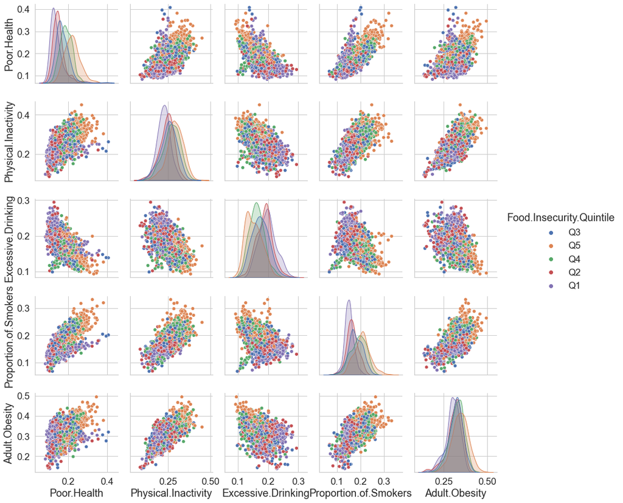

```python
sns.set(style="whitegrid", font_scale=1.5)
tmp_data = county_data[["Poor.Health", "Physical.Inactivity", "Excessive.Drinking", "Proportion.of.Smokers", "Adult.Obesity","Food.Insecurity.Quintile"]]
sns.pairplot(tmp_data, hue="Food.Insecurity.Quintile");
```

## Demographic Characteristics: Percentage of Females

- Next, I examined several demographic characteristics to see how certain demographic factors influenced both poor health and physical inactivity.

```
float64
count    2715.000000
mean        0.500014
std         0.021505
min         0.266000
25%         0.496000
50%         0.504000
75%         0.511000
max         0.570000
Name: Percent.Females, dtype: float64
```

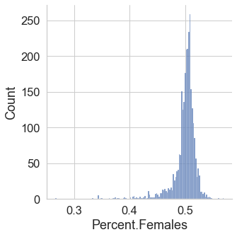

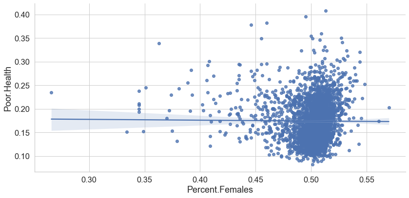

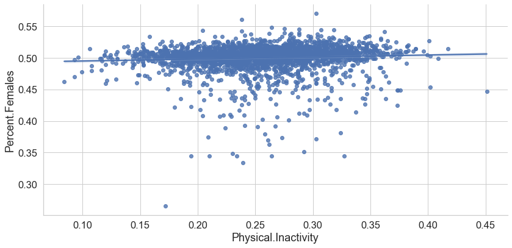

```
                            OLS Regression Results
==============================================================================
Dep. Variable:       Q("Poor.Health")   R-squared:                       0.000
Model:                            OLS   Adj. R-squared:                 -0.000
Method:                 Least Squares   F-statistic:                    0.1813
Date:                Wed, 16 Mar 2022   Prob (F-statistic):              0.670
Time:                        20:20:02   Log-Likelihood:                 4557.0
No. Observations:                2715   AIC:                            -9110.
Df Residuals:                    2713   BIC:                            -9098.
Df Model:                           1
Covariance Type:            nonrobust
========================================================================================
                           coef    std err          t      P>|t|      [0.025      0.975]
----------------------------------------------------------------------------------------
Intercept                0.1830      0.020      9.065      0.000       0.143       0.223
Q("Percent.Females")    -0.0172      0.040     -0.426      0.670      -0.096       0.062
==============================================================================
Omnibus:                      278.986   Durbin-Watson:                   1.035
Prob(Omnibus):                  0.000   Jarque-Bera (JB):              390.808
Skew:                           0.802   Prob(JB):                     1.37e-85
Kurtosis:                       3.937   Cond. No.                         58.1
==============================================================================

Notes:
[1] Standard Errors assume that the covariance matrix of the errors is correctly specified.
                            OLS Regression Results
==============================================================================
Dep. Variable:       Q("Poor.Health")   R-squared:                       0.367
Model:                            OLS   Adj. R-squared:                  0.366
Method:                 Least Squares   F-statistic:                     785.2
Date:                Wed, 16 Mar 2022   Prob (F-statistic):          9.12e-270
Time:                        20:20:02   Log-Likelihood:                 5177.1
No. Observations:                2715   AIC:                        -1.035e+04
Df Residuals:                    2712   BIC:                        -1.033e+04
Df Model:                           2
Covariance Type:            nonrobust
============================================================================================
                               coef    std err          t      P>|t|      [0.025      0.975]
--------------------------------------------------------------------------------------------
Intercept                    0.0959      0.016      5.913      0.000       0.064       0.128
```

[output cut: 25 more lines]

```
Intercept                                         0.4715      0.082      5.748      0.000       0.311       0.632
Q("Physical.Inactivity")                         -0.9243      0.312     -2.965      0.003      -1.536      -0.313
Q("Percent.Females")                             -0.8665      0.164     -5.276      0.000      -1.188      -0.544
Q("Physical.Inactivity"):Q("Percent.Females")     2.9112      0.623      4.671      0.000       1.689       4.133
==============================================================================
Omnibus:                      654.691   Durbin-Watson:                   1.299
Prob(Omnibus):                  0.000   Jarque-Bera (JB):             2228.884
Skew:                           1.183   Prob(JB):                         0.00
Kurtosis:                       6.755   Cond. No.                     1.21e+03
==============================================================================

Notes:
[1] Standard Errors assume that the covariance matrix of the errors is correctly specified.
[2] The condition number is large, 1.21e+03. This might indicate that there are
strong multicollinearity or other numerical problems.
```

```python
## Summary of X var
print(county_data["Percent.Females"].dtypes)

print(county_data["Percent.Females"].describe())
sns.displot(county_data["Percent.Females"]);

sns.lmplot(x="Percent.Females", y="Poor.Health",data=county_data, height=6, aspect=2);
plt.show()

sns.lmplot(x="Physical.Inactivity", y="Percent.Females", data=county_data, height=6,
aspect=2);
plt.show()

health_reg4 = smf.ols(formula = 'Q("Poor.Health") ~ Q("Percent.Females")', data = county_data)
health_reg_res4 = health_reg4.fit()
print(health_reg_res4.summary())

fem_reg = smf.ols(formula = 'Q("Poor.Health") ~ Q("Physical.Inactivity") + Q("Percent.Females")',
                       data = county_data)
fem_reg_res = fem_reg.fit()
print(fem_reg_res.summary())

fem_health_phys = smf.ols(formula = 'Q("Poor.Health") ~ Q("Physical.Inactivity") + Q("Percent.Females") + Q("Physical.Inactivity"):Q("Percent.Females")', data = county_data)
fem_health_phys_res = fem_health_phys.fit()
print(fem_health_phys_res.summary())
```

- The new variable is percentage female. I chose this variable to see if there was any difference across the sexes with poor health and physical inactivity.
- Then, I plotted the relationships between percentage female and poor health as well as physical inactivity and percentage female. Again, there was a lot of variability in points, but a general neutral relationship between percentage female and poor health. There was a general neutral relationship between physical inactivity and percentage female.
- I then ran three different regressions to see the different associations between each of the variables. For the first regression, I just ran percentage female as a predictor variable. For the second, I ran physical inactivity and percentage female as predictor variables. Finally, I ran physical inactivity and percentage female as well as their interaction as predictor variables to see the effect of physical inactivity on the value of percentage female.
- For the first model, the R squared value of 0 indicates that percentage female does not at all explain the variability in poor health. The p value is greater than .05, indicating that percentage female is not a significant predictor of poor health.
- For the second model, the R squared value of .367 indicates that physical inactivity and percentage female do not strongly explain the variability in poor health. The p values are less than .05, indicating that physical inactivity and percentage female are significant predictors of poor health.
- For the third model, the R squared value of .372 indicates that physical inactivity, percentage female, and their interaction do not strongly explain the variability in poor health. All of the predictors are significant when the interaction model was introduced, since their p values were less than .05. The model becomes stronger when the interaction term is introduced, causing the R squared value to increase slightly.

## Demographic Characteristics: Percentage Rural

```
float64
count    2715.000000
mean        0.543305
std         0.304532
min         0.000000
25%         0.302300
50%         0.545000
75%         0.777600
max         1.000000
Name: Percent.Rural, dtype: float64
```

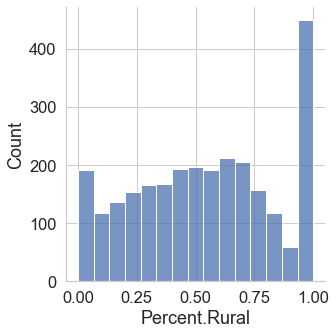

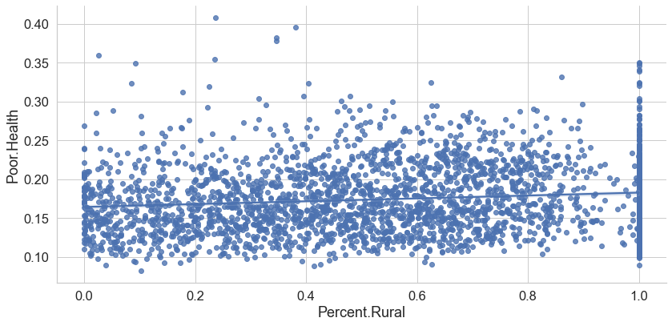

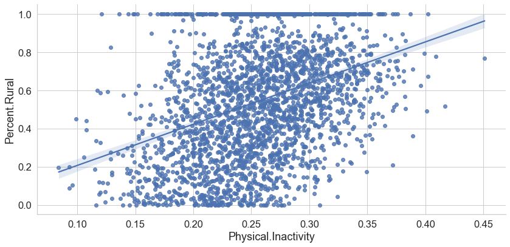

```
                            OLS Regression Results
==============================================================================
Dep. Variable:       Q("Poor.Health")   R-squared:                       0.015
Model:                            OLS   Adj. R-squared:                  0.015
Method:                 Least Squares   F-statistic:                     42.60
Date:                Wed, 16 Mar 2022   Prob (F-statistic):           8.00e-11
Time:                        20:20:27   Log-Likelihood:                 4578.1
No. Observations:                2715   AIC:                            -9152.
Df Residuals:                    2713   BIC:                            -9140.
Df Model:                           1
Covariance Type:            nonrobust
======================================================================================
                         coef    std err          t      P>|t|      [0.025      0.975]
--------------------------------------------------------------------------------------
Intercept              0.1644      0.002     93.386      0.000       0.161       0.168
Q("Percent.Rural")     0.0184      0.003      6.527      0.000       0.013       0.024
==============================================================================
Omnibus:                      282.026   Durbin-Watson:                   1.045
Prob(Omnibus):                  0.000   Jarque-Bera (JB):              407.293
Skew:                           0.791   Prob(JB):                     3.61e-89
Kurtosis:                       4.047   Cond. No.                         4.33
==============================================================================

Notes:
[1] Standard Errors assume that the covariance matrix of the errors is correctly specified.
                            OLS Regression Results
==============================================================================
Dep. Variable:       Q("Poor.Health")   R-squared:                       0.375
Model:                            OLS   Adj. R-squared:                  0.374
Method:                 Least Squares   F-statistic:                     812.4
Date:                Wed, 16 Mar 2022   Prob (F-statistic):          3.35e-277
Time:                        20:20:27   Log-Likelihood:                 5194.2
No. Observations:                2715   AIC:                        -1.038e+04
Df Residuals:                    2712   BIC:                        -1.036e+04
Df Model:                           2
Covariance Type:            nonrobust
============================================================================================
                               coef    std err          t      P>|t|      [0.025      0.975]
--------------------------------------------------------------------------------------------
Intercept                    0.0395      0.003     11.427      0.000       0.033       0.046
```

[output cut: 23 more lines]

```
                                                  coef    std err          t      P>|t|      [0.025      0.975]
---------------------------------------------------------------------------------------------------------------
Intercept                                       0.0624      0.007      9.249      0.000       0.049       0.076
Q("Physical.Inactivity")                        0.4658      0.028     16.416      0.000       0.410       0.521
Q("Percent.Rural")                             -0.0613      0.012     -5.300      0.000      -0.084      -0.039
Q("Physical.Inactivity"):Q("Percent.Rural")     0.1806      0.046      3.948      0.000       0.091       0.270
==============================================================================
Omnibus:                      691.672   Durbin-Watson:                   1.310
Prob(Omnibus):                  0.000   Jarque-Bera (JB):             2387.837
Skew:                           1.246   Prob(JB):                         0.00
Kurtosis:                       6.859   Cond. No.                         93.5
==============================================================================

Notes:
[1] Standard Errors assume that the covariance matrix of the errors is correctly specified.
```

```python
## Summary of X var
print(county_data["Percent.Rural"].dtypes)

print(county_data["Percent.Rural"].describe())
sns.displot(county_data["Percent.Rural"]);

sns.lmplot(x="Percent.Rural", y="Poor.Health",data=county_data, height=6, aspect=2);
plt.show()

sns.lmplot(x="Physical.Inactivity", y="Percent.Rural", data=county_data, height=6,
aspect=2);
plt.show()

health_reg5 = smf.ols(formula = 'Q("Poor.Health") ~ Q("Percent.Rural")', data = county_data)
health_reg_res5 = health_reg5.fit()
print(health_reg_res5.summary())

rural_reg = smf.ols(formula = 'Q("Poor.Health") ~ Q("Physical.Inactivity") + Q("Percent.Rural")',
                       data = county_data)
rural_reg_res = rural_reg.fit()
print(rural_reg_res.summary())

rural_health_phys = smf.ols(formula = 'Q("Poor.Health") ~ Q("Physical.Inactivity") + Q("Percent.Rural") + Q("Physical.Inactivity"):Q("Percent.Rural")', data = county_data)
rural_health_phys_res = rural_health_phys.fit()
print(rural_health_phys_res.summary())
```

- The new variable is percentage rural. I chose this variable to see if there was any difference across rural vs urban people with poor health and physical inactivity.
- Then, I plotted the relationships between percentage rural and poor health as well as physical inactivity and percentage rural. Again, there was a lot of variability in points, but a general neutral relationship between percentage rural and poor health. There was a general positive relationship between physical inactivity and percentage rural.
- I then ran three different regressions to see the different associations between each of the variables. For the first regression, I just ran percentage rural as a predictor variable. For the second, I ran physical inactivity and percentage rural as predictor variables. Finally, I ran physical inactivity and percentage rural as well as their interaction as predictor variables to see the effect of physical inactivity on the value of percentage rural.
- For the first model, the R squared value of .015 indicates that percentage rural does not at all strongly explain the variability in poor health. The p value is less than .05, indicating that percentage rural is a significant predictor of poor health.
- For the second model, the R squared value of .375 indicates that physical inactivity and percentage rural does not strongly explain the variability in poor health. The p value is less than .05, indicating that physical inactivity and percentage rural are significant predictors of poor health.
- For the third model, the R squared value of .378 indicates that physical inactivity, percentage rural, and their interaction moderately explains the variability in poor health. All of the predictors are significant when the interaction model was introduced, since their p values were less than .05. Again, the model becomes stronger when the interaction term is introduced, causing the R squared value to increase slightly.

## Decision Tree

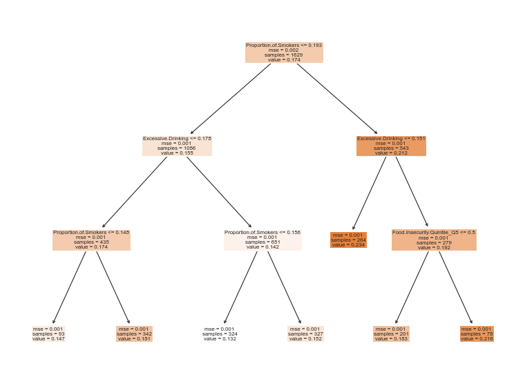

```python
from sklearn.model_selection import train_test_split
from sklearn import tree
import sklearn

Xcts = county_data[["Physical.Inactivity", "Excessive.Drinking",
                    "Proportion.of.Smokers", "Adult.Obesity","Percent.Rural","Percent.Females"]]
Xcts = pd.DataFrame(data=Xcts)

Xcat = county_data[["Food.Insecurity.Quintile"]]
Xcat = pd.DataFrame(data=Xcat)

Xcat_dum = pd.get_dummies(Xcat)

X = pd.merge(Xcts, Xcat_dum,left_index=True,right_index=True)
y = county_data["Poor.Health"]

# Create the train/test split
X_train, X_test, y_train, y_test = train_test_split(X, y, test_size = 0.4, random_state=1940)

regtree = tree.DecisionTreeRegressor(random_state=0, max_leaf_nodes=7)
regtree.fit(X_train, y_train)

fig = plt.figure(num=None, figsize=(12, 9), dpi=80, facecolor='w', edgecolor='k')
tree.plot_tree(regtree, filled=True, feature_names=X.columns);
pass
```

- To round out my analysis, I created a decision tree using the variables Physical.Inactivity, Excessive.Drinking, Proportion.of.Smokers, Adult.Obesity, Percent.Rural, and Percent.Females.
- I chose to limit the nodes in the tree to 7 to preserve readability and comprehension.
- The key variables in the tree are proportion of smokers, excessive drinking, and food insecurity quintile. This makes sense, since each of these variables had significant predictors for Poor Health.
- In this case, the largest value was .234, which was found when proportion of smokers was greater than .193, and when excessive drinking was less than or equal to .151. In this bucket, there are 264 samples. Another high value was .216, which occured when proportion of smokers was greater than .193, excessive drinking was greater than .151, and food insecurity quintile was Q5. This makes sense with our earlier analysis, showing that being in Q5 and having a high proportion of smokers leads to poor health outcomes at a greater frequency.
- For the best health, these are the ones with the lowest value for poor health outcomes, which is .132. These are when proportion of smoking is below or equal to .156 and excessive drinking is above .17. This follows the trend from before where low proportion of smoking correlates with better health outcomes, but more excessive drinking actually correlates with better health outcomes as well.

## Cost Complexity Pruning

```
0.5752011115513878
```

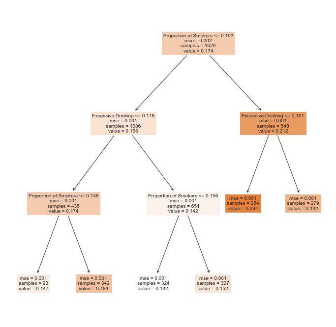

```python
dtr = tree.DecisionTreeRegressor(random_state=1940)
path = dtr.cost_complexity_pruning_path(X_train, y_train)
ccp_alphas, impurities = path.ccp_alphas, path.impurities


rgrs = []
for ccp_alpha in ccp_alphas:
    dtr = tree.DecisionTreeRegressor(random_state=1940, max_leaf_nodes=6,ccp_alpha=ccp_alpha,max_depth=4)
    dtr.fit(X_train, y_train)
    rgrs.append(dtr)

train_scores = [dtr.score(X_train, y_train) for dtr in rgrs]
test_scores = [dtr.score(X_test, y_test) for dtr in rgrs]


best = pd.Series(test_scores).idxmax()

print(test_scores[best])
best_tree = rgrs[best]

fig2 = plt.figure(num=None, figsize=(12, 12), facecolor='w', edgecolor='k')
tree.plot_tree(best_tree, filled=True, fontsize=10,feature_names=X.columns);
pass
```

- Next, I did cost-complexity pruning to mitigate the effect of over or under fitting. I wanted to remove the weakest link in the tree, creating a tree to explore for the best generalizability.
- However, this tree ended up being very similar to the original decision tree that was generated. This could mean that the original data did not suffer from over or underfitting to the model. I set the max leaf nodes to 6 for readability again.
- Then, I printed the best tree as well as the test score at best. The r squared value for the tree was .575, which is one of the higher values that we have observed throughout the project.

# Conclusions

## Suggestions for further research

1. First, I would find more data on the relationship between excessive drinking and diet. I was surprised by the result in the data that there was not a positive correlation between excessive drinking and poor health outcomes. I would like to get more data on drinking habits and nutrition on the county level to explore this issue more.
2. Next, I would be interested in verifying results for new time periods. Then, I could employ a longitudinal study to see if poor health outcomes change over time and how fluctuating physical inactivity is similarly altered. It would also be interesting to do a pre COVID and current time period analysis to see if COVID improved or hurt physical inactivity and its impact on poor health outcomes.
3. Finally, I would be interested in segmenting the data deeper by age, to see if younger or older age brackets have different outcomes. For states like Florida, I noticed in my analysis some outliers, so I would be interested in seeing if that was due to Florida having an older state population.